# 12. Stop names and data

Communications adjusts stop names and other text associated with places. This information is stored in the Stops_Neue table in FileMaker.

# Import adjustments

The “newsignup” program imports the stops data from the Enterprise Database export from Hastus and then makes some modifications before it’s saved to be imported into FileMaker.

The import adjustment routine is in the sub “hastus_stops_import” in the module “Octium::Import::CalculateFields”. It does several modifications:

- It divides the stop description into separate fields for the “on street” (field i_on), “at street” (field i_at), address number (field i_street_num), and additional comment text (field i_comment)
- It makes a series of additional editorial changes. I won’t go into those specifically, they’re in the [code](https://github.com/aaronpriven/actium/blob/main/lib/Octium/Import/CalculateFields.pm) and it’s not too difficult to get the gist even for those who don’t understand the technical part, but it does things like spelling out or adding periods to street name abbreviations, changing “BART Station” to “BART”, changing “MLK” to “Martin Luther King Jr.”, and so forth.
- It determines a default direction of travel (field i_direction) from the corner and “site” (near side / far side)
- It creates a default city name (field i_city), based on the “district” encoded in Hastus (1 = Alameda, 2 = Albany, 3.= Berkeley, etc., down to 99 = Contra Costa County).

# Default / override / final

Several of the fields work this way: there’s a default, provided by either the Hastus export or an automatic adjustment of the Hastus export. The user then has the opportunity to override that by entering data into an override field. A third field, a calculated field (I think these are called “computed fields” in some database systems), holds whatever the final result is – the default, or the overridden value if there is one. If the override value is just a period, the result will be empty.

# Field name convention

There is a convention for the field names. Fields beginning:

h_ come from the Hastus export without modification

i_ are adjustments to the Hastus export made by the newsignup program

o_ are fields that allow overriding either an h_ or i_ field

c_ are calculated fields, including a bunch of “if there’s an o_ entry, use it, otherwise use the default” fields.

p_ are fields calculated by one of the actium.pl programs, other than adjustments to Hastus made by the newsignup program

u_ are fields entered from scratch by the FileMaker user

If it has an “x” in the header, this means that this isn’t used now.

# Communications contributed data

Communications contributes a number of pieces of data.

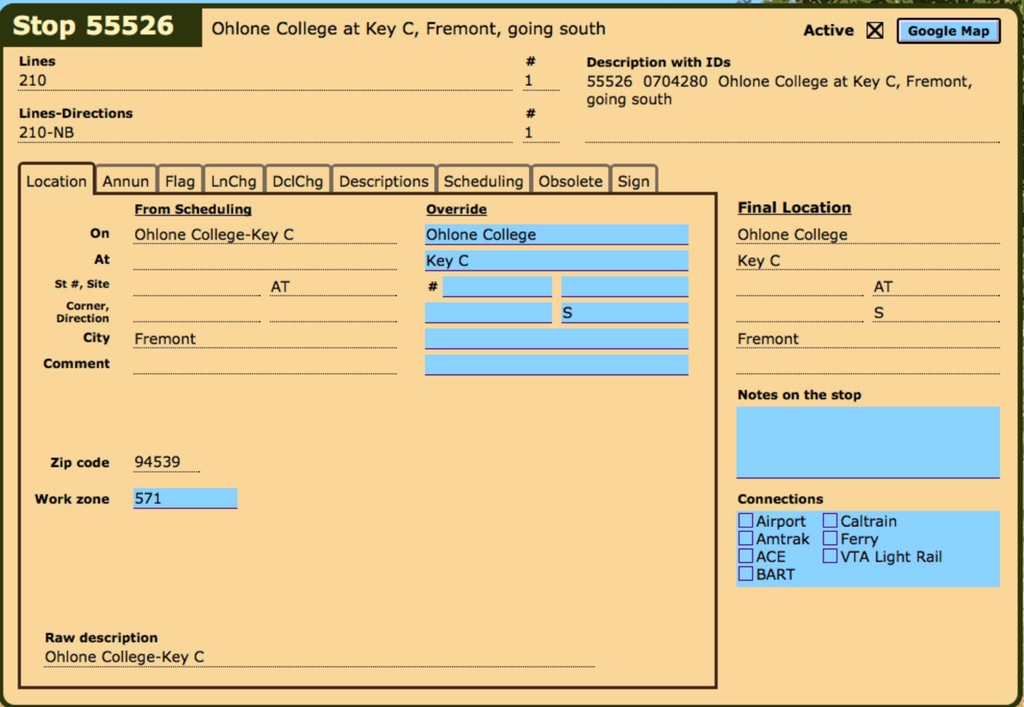

- Potentially override values derived from the stop description: on (o_on, c_on), at (o_at, c_at), address number (o_street_num, c_street_num), and comment (o_comment, c_comment).
- Potentially override the corner (o_corner, c_corner), site (o_site, c_site), and direction of travel (o_direction, c_direction). As far as I know, this data is the best information AC Transit has on direction of travel, since this doesn’t come from Hastus and I have been looking it up when new stops were created. Corner and site are mainly overridden when the name gets changed, since a stop can be on one corner when the name refers to one street, and another corner when the name refers to another.
- Work zone (u_work_zone) is an arbitrary number used for making clusters of work for the pole crew. Nearby stops share a work zone.
- Zip code (p_zip_code) is the zip code of the stop (which was mainly important because the original work zone assignment used zip codes as its base). This is looked up from geonames.org (see get_zip_for_stops in [Octium::Geo](https://github.com/aaronpriven/actium/blob/main/lib/Octium/Geo.pm) )
- Connections (u_connections) was used for setting the icons in the flag specification program
- Lines (p_lines), Lines-directions (p_linedirs), and active status (p_active) are set by importing the result from “actium.pl avl2stoplines”.
- There are a series of calculated field descriptions, basically putting together formulas based on the other values. Different formulas are used in different places, depending on the needs at the time. The most complete one is c_description_full; c_description_fullabbr has the same information but more abbreviated; c_description_short and c_description_nocity don’t have quite as much information; c_at_long is similar but omits the “on” street, which makes it useful for sorting.
- At one point a few years ago I started writing new names (o_description_for_hastus) that were suggestions for replacing the description used in Hastus, including its then-use of colons to separate on and at streets, and its length limitations. This probably needs to be looked at again.

Except for the annunciation fields, which I’ll describe in a future document, I believe other fields are no longer used. I may have missed something.

# Issues and Future

Segmenting the undifferentiated “description” field that comes from Hastus is very important for annunciation, and using the names as they are now in Hastus would lose improvements of stop names as they appear on at-stop signs and any of the other work that I’ve done.

It’s possible to imagine a system that originates the name data feeding Hastus rather than the other way around. That would be cleaner and not require the same kinds of overrides that are necessary now. Having said that, it would have to be adjusted to allow quicker response than is possible in Hastus.